# Data Visualization ggplot2

From Raw Data to Regional Insights: Intermediate R Tools for Workforce & Economic Development

Nov 19-20, 2025

# Introduction

This document is a hands-on script for our data visualization session, focused on using ggplot2 to transform raw economic data into clear, publication-quality charts. Throughout this workshop, we will pull real-time data from federal APIs—including FRED, BLS, and BEA—clean the outputs with the tidyverse, and build visualizations that support workforce and economic development analysis.

`ggplot2` is the core tool in this workflow. It follows the Grammar of Graphics framework, meaning every chart is built step by step:

- you choose the dataset,
- map variables to visual elements (aesthetics),
- add geometric layers such as lines, bars, and points,
- customize scales, themes, labels, and annotations.

This structure makes your charts reproducible, customizable, and easy to update as new data arrives.

Each section in this file follows a consistent workflow:

- Download data from an official API
- Clean or reshape the data
- Visualize with ggplot2
- Try exercises to adapt the code to your own agency use cases

This file serves as both a live-coding script for the training and a template for producing your own ongoing charts and reports.

## 1. Visualizing FRED data with `ggplot2`

In this section, we use the **FRED** (Federal Reserve Economic Data) API to download macroeconomic time series directly into R and visualize them with `ggplot2`. The **fredr** package provides a convenient interface to the FRED RESTful API. For package documentation, see: https://sboysel.github.io/fredr/.

You will need to request a FRED API key here: https://fred.stlouisfed.org/docs/api/api_key.html. Once you have your key, you can register it in R as follows (replace the placeholder string with your own key):

```r
# install.packages("fredr")
```

```r
# Load library
library(fredr)
library(tidyverse)
library(ggplot2)

# Register the key for this R session
fredr_set_key(Sys.getenv("FRED_API_KEY"))
```

### 1.1 Download a single FRED series

Here we download the U.S. unemployment rate (`UNRATE`) series from FRED.

```r
unemp <- fredr(series_id = "UNRATE")
```

```r
unemp
```

| date | series_id | value | realtime_start | realtime_end |
| --- | --- | --- | --- | --- |
| 1948-01-01 | UNRATE | 3.4 | 2025-09-30 | 2025-09-30 |
| 1948-02-01 | UNRATE | 3.8 | 2025-09-30 | 2025-09-30 |
| 1948-03-01 | UNRATE | 4.0 | 2025-09-30 | 2025-09-30 |
| 1948-04-01 | UNRATE | 3.9 | 2025-09-30 | 2025-09-30 |
| 1948-05-01 | UNRATE | 3.5 | 2025-09-30 | 2025-09-30 |
| 1948-06-01 | UNRATE | 3.6 | 2025-09-30 | 2025-09-30 |
| 1948-07-01 | UNRATE | 3.6 | 2025-09-30 | 2025-09-30 |
| 1948-08-01 | UNRATE | 3.9 | 2025-09-30 | 2025-09-30 |
| 1948-09-01 | UNRATE | 3.8 | 2025-09-30 | 2025-09-30 |
| 1948-10-01 | UNRATE | 3.7 | 2025-09-30 | 2025-09-30 |

[output cut: 922 more lines]

### 1.2 Plotting unemployment data with `ggplot2`

We start with a simple line plot of the unemployment rate.

`ggplot()` is used to construct the initial plot object, and is almost always followed by a plus sign (+) to add components to the plot.

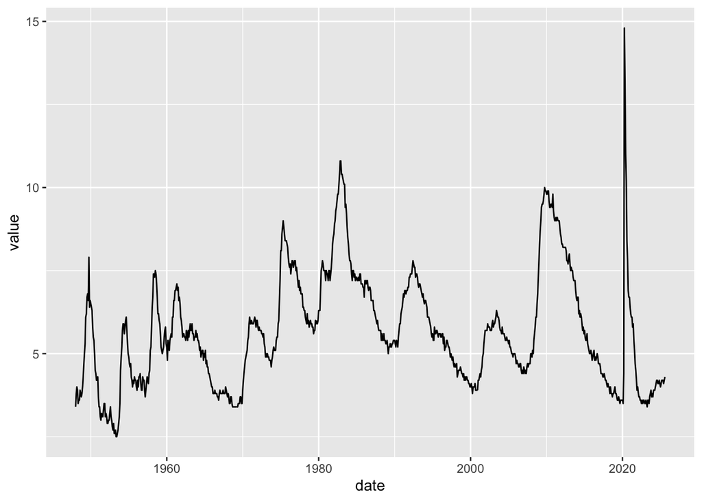

```r
# Basic line plot
urate_plot <- ggplot(               # Initialize a ggplot object
  data = unemp,                     # Use 'unemp' as the data source
  aes(x = date, y = value)) +       # Map 'date' to x-axis and 'value' to y-axis
  geom_line()                       # Add a line layer to visualize the trend over time

urate_plot                          # Display the resulting plot
```

Next, we define a simple custom theme and apply it to the plot:

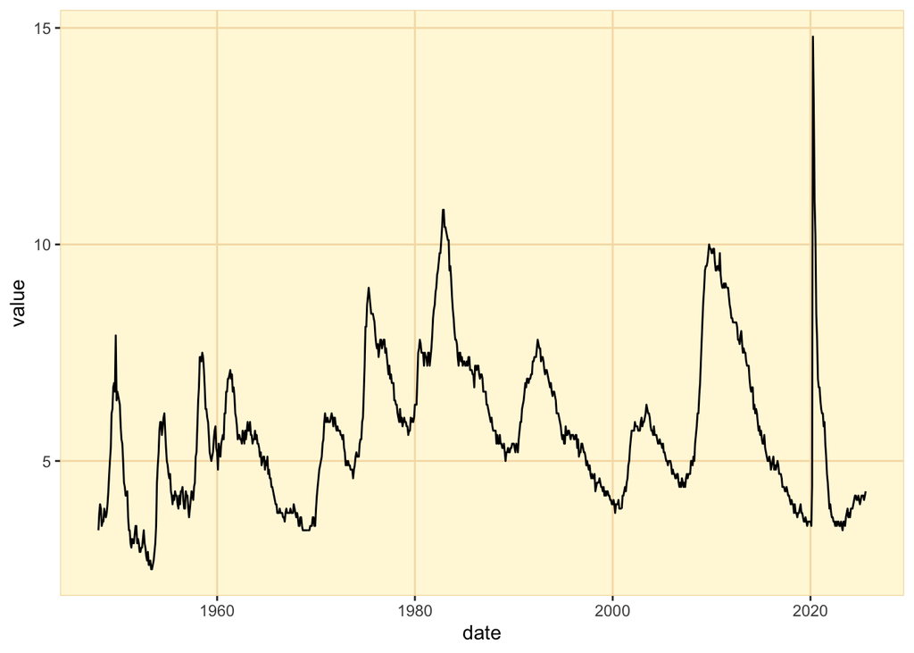

```r
# Creating our own theme
my_theme <- theme(
  panel.background = element_rect(fill = "cornsilk", color = "wheat"),
  panel.grid.major = element_line(color = "wheat"),
  panel.grid.minor = element_blank()
)

# Line plot with customized theme
urate_plot <- urate_plot + my_theme
urate_plot
```

### 1.3 Multiple FRED series

Often we want to compare several series (e.g., unemployment rate and the federal funds rate). Here we use `purrr::map_dfr()` to download multiple series and combine them into a single data frame.

```r
data <- purrr::map_dfr(c("UNRATE", "FEDFUNDS"), fredr)
```

```r
data
```

| date | series_id | value | realtime_start | realtime_end |
| --- | --- | --- | --- | --- |
| 1948-01-01 | UNRATE | 3.40 | 2025-09-30 | 2025-09-30 |
| 1948-02-01 | UNRATE | 3.80 | 2025-09-30 | 2025-09-30 |
| 1948-03-01 | UNRATE | 4.00 | 2025-09-30 | 2025-09-30 |
| 1948-04-01 | UNRATE | 3.90 | 2025-09-30 | 2025-09-30 |
| 1948-05-01 | UNRATE | 3.50 | 2025-09-30 | 2025-09-30 |
| 1948-06-01 | UNRATE | 3.60 | 2025-09-30 | 2025-09-30 |
| 1948-07-01 | UNRATE | 3.60 | 2025-09-30 | 2025-09-30 |
| 1948-08-01 | UNRATE | 3.90 | 2025-09-30 | 2025-09-30 |
| 1948-09-01 | UNRATE | 3.80 | 2025-09-30 | 2025-09-30 |
| 1948-10-01 | UNRATE | 3.70 | 2025-09-30 | 2025-09-30 |

[output cut: 1778 more lines]

Now we make a quick chart of both series:

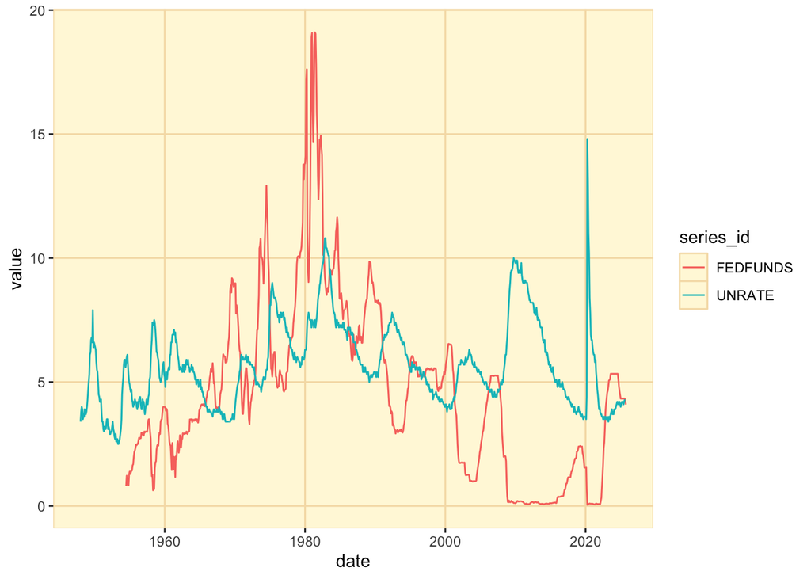

```r
# Basic line plot for multiple series
data %>%                              # Pipe the data forward
  ggplot(aes(                         # Initialize ggplot and set aesthetics
    x     = date,                     # x-axis = date
    y     = value,                    # y-axis = numeric value
    color = series_id                 # Use series_id to color different series
  )) +
  geom_line() +                       # Draw a line for each series
  my_theme                            # Apply a custom theme
```

We can also customize the color scale to use specific colors:

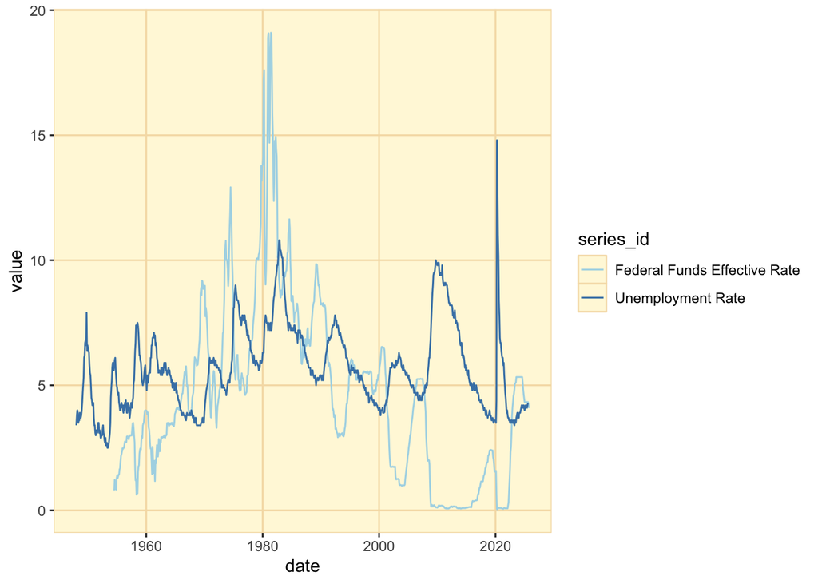

```r
data |>
  ggplot(aes(
    x     = date,
    y     = value,
    color = series_id
  )) +
  geom_line() +
  scale_color_manual(values = c(UNRATE = "steelblue", FEDFUNDS = "lightblue"),
                     labels = c(UNRATE = "Unemployment Rate", FEDFUNDS = "Federal Funds Effective Rate")) +
  my_theme
```

### 1.4 Plotting bar charts

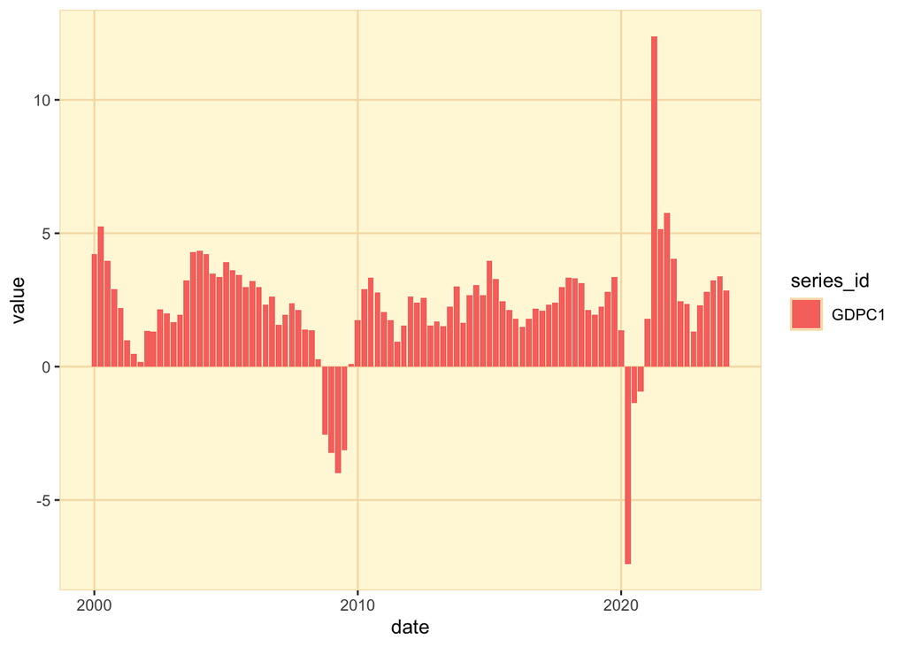

```r
# Download Real Gross Domestic Product
rgdp <- fredr(
  series_id         = "GDPC1",
  observation_start = as.Date("2000-01-01"),
  observation_end   = as.Date("2024-01-01"),
  frequency         = "q",   # quarterly
  units             = "pc1"  # percent change from 1 year ago
)

# Plot bar charts
rgdp |>
  ggplot(aes(
    x    = date,
    y    = value,
    fill = series_id
  )) +
  # geom_bar(stat = "identity") +
  geom_col() +
  my_theme
```

### 1.6 Exercises: FRED

1. Use `fredr()` to download the U.S. **CPI** for all urban consumers (`CPIAUCSL`), starting from 2010.
2. Create a line chart of CPI with a different color and add a title and axis labels.

## 2. Visualizing BLS data with `ggplot2`

In this section, we use the **Bureau of Labor Statistics (BLS)** API to download job openings data from the JOLTS program and visualize it with `ggplot2`. We will use the **blsAPI** package, which wraps the BLS public API. You must request your own BLS API key here: https://data.bls.gov/registrationEngine/

### 2.1 Download data with `blsAPI`

```r
library(blsAPI)

# Replace with your own BLS API key
bls_key <- Sys.getenv("BLS_API_KEY")

df <- blsAPI(
  list(
    'seriesid'       = c("JTS000000000000000JOR", "JTS000000340000000JOR"), # US total, New Jersey
    'startyear'      = 2018,
    'endyear'        = 2025,
    'annualaverage'  = FALSE,
    'calculations'   = FALSE,
    'catalog'        = TRUE,
    'registrationKey'= bls_key
  ),
  api_version       = 2,
  return_data_frame = TRUE
)
```

### 2.2 Tidy data for plotting

The BLS API returns year and period (e.g., `"M01"` for January). We convert these to a proper date, create state labels, and keep only observations where we have both U.S. and New Jersey data.

```r
df_cleaned <- df %>%
  mutate(
    yom        = as.Date(paste0(year, "-", substr(period, 2, 3), "-01"), format = "%Y-%m-%d"),
    value      = as.numeric(value),
    state      = substr(seriesID, 10, 11),
    state_name = ifelse(state == "00", "United States", NA),
    state_name = ifelse(state == "34", "New Jersey", state_name)
  ) %>%
  group_by(yom) %>%
  filter(n() == 2)

df_cleaned
```

| year | period | periodName | value | seriesID | yom | state | state_name |
| --- | --- | --- | --- | --- | --- | --- | --- |
| 2025 | M07 | July | 4.3 | JTS000000000000000JOR | 2025-07-01 | 00 | United States |
| 2025 | M06 | June | 4.4 | JTS000000000000000JOR | 2025-06-01 | 00 | United States |
| 2025 | M05 | May | 4.6 | JTS000000000000000JOR | 2025-05-01 | 00 | United States |
| 2025 | M04 | April | 4.4 | JTS000000000000000JOR | 2025-04-01 | 00 | United States |
| 2025 | M03 | March | 4.3 | JTS000000000000000JOR | 2025-03-01 | 00 | United States |
| 2025 | M02 | February | 4.5 | JTS000000000000000JOR | 2025-02-01 | 00 | United States |
| 2025 | M01 | January | 4.7 | JTS000000000000000JOR | 2025-01-01 | 00 | United States |
| 2024 | M12 | December | 4.5 | JTS000000000000000JOR | 2024-12-01 | 00 | United States |
| 2024 | M11 | November | 4.8 | JTS000000000000000JOR | 2024-11-01 | 00 | United States |
| 2024 | M10 | October | 4.6 | JTS000000000000000JOR | 2024-10-01 | 00 | United States |

[output cut: 172 more lines]

### 2.3 Basic line plot

We start with a simple time-series of the U.S. job openings rate.

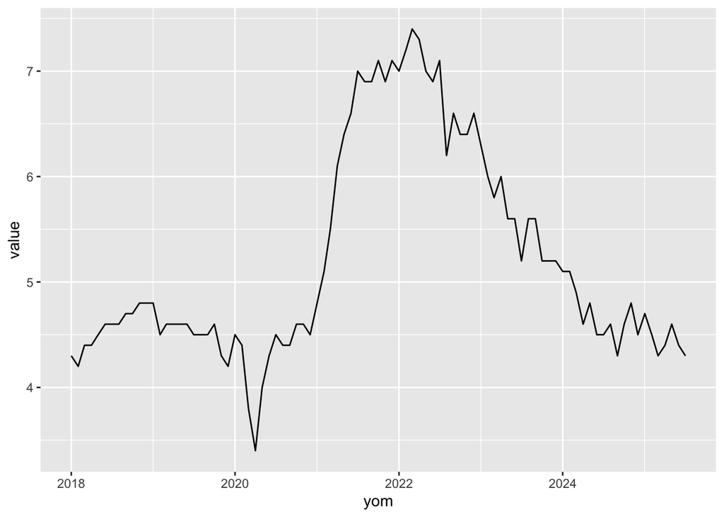

```r
plot <- df_cleaned %>%
  filter(state == "00") %>%
  ggplot() +
  geom_line(aes(x = yom, y = value))

plot
```

### 2.4 Enhanced line plot with labels and shaded recession

Here we customize the line, add titles and labels, and shade the 2020 recession.

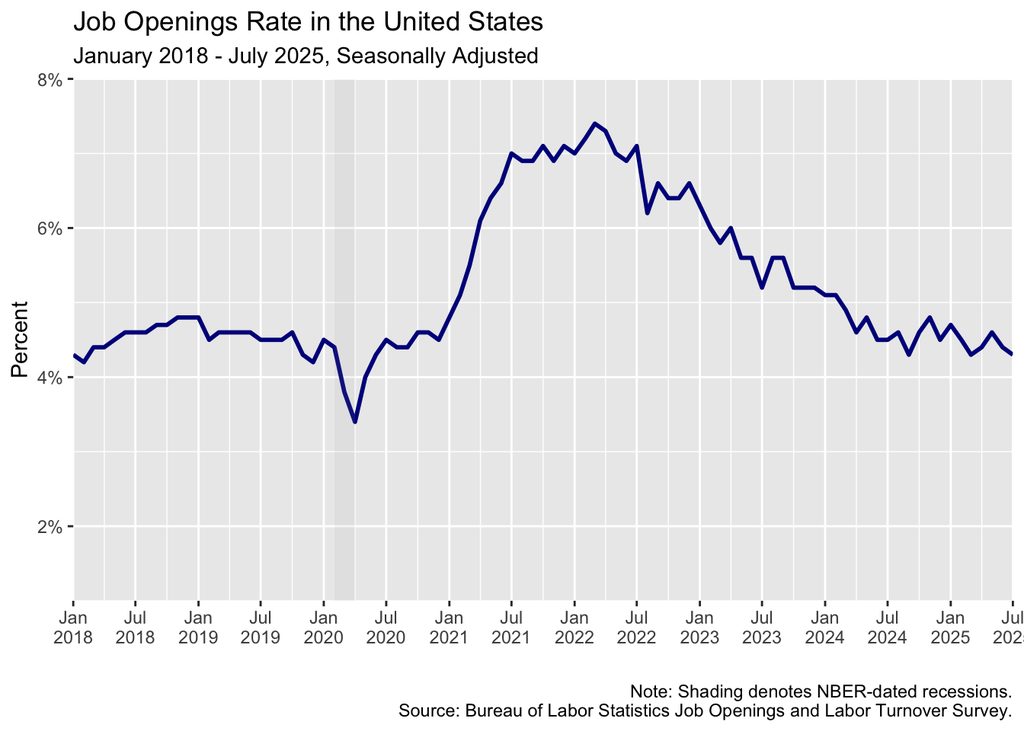

```r
plot_1 <- df_cleaned %>%
  filter(state == "00") %>%
  ggplot() +
  geom_line(
    aes(x = yom, y = value),
    color    = "darkblue",
    linetype = "solid",
    linewidth= 1
  ) +
  labs(
    title    = "Job Openings Rate in the United States",
    subtitle = "January 2018 - July 2025, Seasonally Adjusted",
    caption  = "Note: Shading denotes NBER-dated recessions.\nSource: Bureau of Labor Statistics Job Openings and Labor Turnover Survey.",
    x        = "",
    y        = "Percent"
  ) +
  scale_y_continuous(
    expand = c(0, 0),
    limits = c(1, 8),
    labels = scales::label_percent(accuracy = 1, scale = 1)
  ) +
  scale_x_date(
    expand      = c(0, 0),
    date_labels = "%b\n%Y",
    breaks      = "6 month"
  ) +
  annotate(
    "rect",
    xmin  = as.Date("2020-02-01"),
    xmax  = as.Date("2020-04-01"),
    ymin  = -Inf,
    ymax  = Inf,
    alpha = .1,
    fill  = "darkgrey"
  )

plot_1
```

### 2.5 A custom DOL-style theme

We define a reusable theme tailored for labor-market charts:

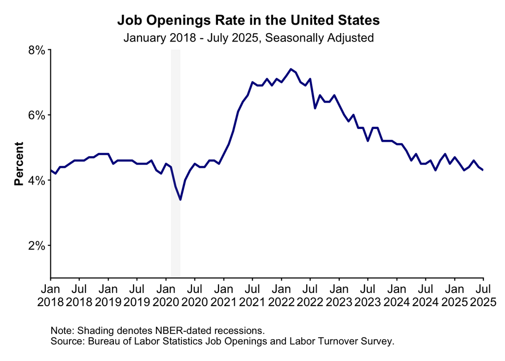

```r
theme_dol <- function(){
  theme_classic() +
    theme(
      # remove gridlines
      panel.grid.major = element_blank(),
      panel.grid.minor = element_blank(),

      # text elements
      plot.title      = element_text(size = 14, face = 'bold', hjust = 0.5),
      plot.subtitle   = element_text(size = 12, hjust = 0.5),
      plot.caption    = element_text(hjust = 0, size = 10),
      axis.title      = element_text(size = 12, face = 'bold', vjust = 3),
      axis.text.x     = element_text(angle = 0, vjust = 0.5, hjust = 0.5, colour = "black", size = 12),
      axis.text.y     = element_text(colour = "black", size = 12),
      axis.line       = element_line(colour = "black"),

      # legend
      legend.text     = element_text(size = 10.5, face = 'bold'),
      legend.title    = element_blank(),
      legend.position = "top",

      # panel
      panel.border    = element_blank(),
      panel.background= element_blank(),

      plot.margin     = margin(1, 1.5, 1, 1, "lines"),
      plot.title.position = "plot"
    )
}

plot_1 + theme_dol()
```

### 2.6 Plotting multiple series (U.S. vs. New Jersey)

Finally, we plot both the U.S. and New Jersey job openings rates on the same chart.

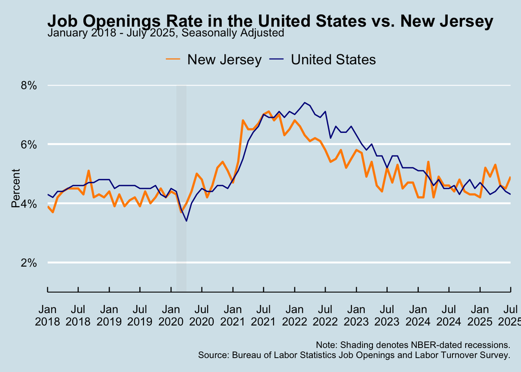

```r
library(ggthemes)

plot_multi <- df_cleaned %>%
  ggplot() +
  geom_line(
    aes(
      x        = yom,
      y        = value,
      group    = state_name,
      color    = state_name,
      linetype = state_name,
      linewidth= state_name
    )
  ) +
  labs(
    title    = "Job Openings Rate in the United States vs. New Jersey",
    subtitle = "January 2018 - July 2025, Seasonally Adjusted",
    caption  = "Note: Shading denotes NBER-dated recessions.\nSource: Bureau of Labor Statistics Job Openings and Labor Turnover Survey.",
    x        = "",
    y        = "Percent"
  ) +
  guides(
    color    = guide_legend(title = "", ncol = 3),
    linetype = "none",
    linewidth= "none"
  ) +
  scale_colour_manual(values   = c("darkorange", "darkblue")) +
  scale_linetype_manual(values = c("solid", "solid")) +
  scale_linewidth_manual(values = c(1, 0.6)) +
  scale_y_continuous(
    expand = c(0, 0),
    limits = c(1, 8),
    labels = scales::label_percent(accuracy = 1, scale = 1)
  ) +
  scale_x_date(
    expand      = c(0, 0),
    date_labels = "%b\n%Y",
    breaks      = "6 month"
  ) +
  annotate(
    "rect",
    xmin  = as.Date("2020-02-01"),
    xmax  = as.Date("2020-04-01"),
    ymin  = -Inf,
    ymax  = Inf,
    alpha = .1,
    fill  = "darkgrey"
  ) +
  theme_economist()

plot_multi
```

### 2.7 Exercises: BLS

1. Modify the query to download data only through **2023** instead of 2025.
2. Change the y-axis label to “Job openings rate (percent)” and adjust the y-axis limits as needed.
3. Add a vertical line (`geom_vline`) to highlight a month of interest (for example, a peak in openings).
4. Create a version of `plot_multi` where:
   - New Jersey is highlighted with a thicker line,
   - The U.S. series is shown in a lighter color.

## 3. Visualizing BEA data with `ggplot2`

In this section, we use the **Bureau of Economic Analysis (BEA)** API to download real GDP data and compare growth rates for the United States and New Jersey.

We will use the **bea.R** package. For details, see the package documentation and examples: https://github.com/us-bea/bea.R

You must request your own BEA API key here: https://apps.bea.gov/API/signup/

### 3.1 Setup and API key

```r
# Load library
library(bea.R)

# Replace with your own BEA API key
beaKey <- Sys.getenv("BEA_API_KEY")
```

### 3.2 Download GDP data with `beaGet`

We first download quarterly U.S. GDP from the NIPA tables and then regional GDP for New Jersey.

```r
# Download GDP data for US
rgdp_us_pc <- beaGet(
  list(
    'UserID'      = beaKey,
    'Method'      = 'GetData',
    'datasetname' = 'NIPA',
    'TableName'   = 'T10101',
    'Frequency'   = 'Q',
    'Year'        = '2024,2025',
    'ResultFormat'= 'json'
    ),
  asWide = FALSE
)

# Download GDP data for NJ
gdp_nj <- beaGet(
  list(
    'UserID'      = beaKey,
    'Method'      = 'GetData',
    'datasetname' = 'REGIONAL',
    'TableName'   = 'SQGDP1',
    'LineCode'    = 'ALL',
    'GeoFIPS'     = '34000',
    'Year'        = '2024,2025',
    'ResultFormat'= 'json'
  ),
  asWide = FALSE
)
```

### 3.3 Tidy data for plotting

We filter the U.S. data to overall GDP and compute approximate annualized growth for New Jersey. Then we combine the two.

```r
rgdp_us_pc_cleaned <- rgdp_us_pc %>%
  filter(LineDescription == "Gross domestic product") %>%
  rename(pc_a = DataValue) %>%
  mutate(
    pc_a  = as.numeric(pc_a),
    place = "United States"
  )

rgdp_nj_pc_cleaned <- gdp_nj %>%
  filter(CL_UNIT == "Millions of chained 2017 dollars") %>%
  arrange(TimePeriod) %>%
  mutate(
    pc_a  = round(100 * ((DataValue / lag(DataValue))^4 - 1), 1),
    place = "New Jersey"
  )

rgdp_pc_lateset <- bind_rows(rgdp_us_pc_cleaned, rgdp_nj_pc_cleaned) %>%
  rename(yoq = TimePeriod) %>%
  select(yoq, pc_a, place) %>%
  mutate(year = as.numeric(substr(yoq, 1, 4))) %>%
  na.omit() %>%
  filter(year >= max(year) - 1) %>%
  group_by(yoq) %>%
  filter(n() == 2) %>%
  ungroup()

rgdp_pc_lateset
```

| yoq | pc_a | place | year |
| --- | --- | --- | --- |
| 2024Q2 | 3.6 | United States | 2024 |
| 2024Q3 | 3.3 | United States | 2024 |
| 2024Q4 | 1.9 | United States | 2024 |
| 2025Q1 | -0.6 | United States | 2025 |
| 2025Q2 | 3.8 | United States | 2025 |
| 2024Q2 | 2.2 | New Jersey | 2024 |
| 2024Q3 | 2.3 | New Jersey | 2024 |
| 2024Q4 | 1.4 | New Jersey | 2024 |
| 2025Q1 | 0.4 | New Jersey | 2025 |
| 2025Q2 | 2.8 | New Jersey | 2025 |

### 3.4 Plotting GDP growth with `ggplot2`

Finally, we create a grouped bar chart comparing real GDP growth (at annual rates) for New Jersey and the United States.

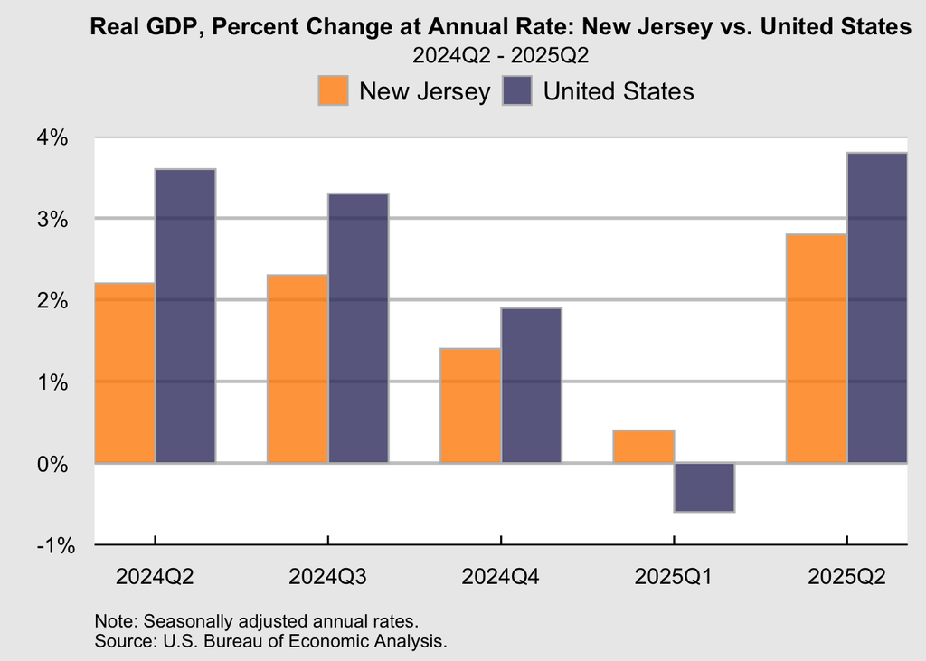

```r
rgdp_pc_lateset %>%
  ggplot() +
  geom_bar(
    aes(
      x    = yoq,
      y    = pc_a,
      fill = factor(place)
    ),
    color   = "grey",
    stat    = "identity",
    position= "dodge",
    width   = 0.7,
    alpha   = 0.8
  ) +
  labs(
    title   = "Real GDP, Percent Change at Annual Rate: New Jersey vs. United States",
    subtitle= paste0(min(rgdp_pc_lateset$yoq), " - ", max(rgdp_pc_lateset$yoq)),
    caption = "Note: Seasonally adjusted annual rates.\nSource: U.S. Bureau of Economic Analysis.",
    x       = "",
    y       = "",
    fill    = ""
  ) +
  scale_fill_manual(values = c("darkorange", "#3b3b6d")) +
  scale_x_discrete(expand = c(0, 0)) +
  scale_y_continuous(
    expand = c(0, 0),
    limits = c(-1, 4),
    labels = function(x) paste0(x, "%")
  ) +
  theme_economist_white(
    base_size = 10,
    horizontal = TRUE
  ) +
  theme(
    plot.title   = element_text(size = 13, face = 'bold', hjust = 0.5, vjust = 2),
    plot.subtitle= element_text(size = 12, hjust = 0.5),
    plot.caption = element_text(hjust = 0, size = 10, vjust = -2),
    axis.text.x  = element_text(size = 12, angle = 0, hjust = 0.5),
    axis.text.y  = element_text(size = 12)
  )
```

# Summary

- Learned a complete API-to-visualization workflow using FRED, BLS, and BEA data.
- Cleaned and reshaped raw API outputs with the tidyverse.
- Built clear, reproducible charts using ggplot2 and its Grammar-of-Graphics structure.
- Developed templates you can reuse for monthly updates, state reports, and future data products.